# Steps Analysis

P. Mae Cooper

November 5, 2019

```r
library(lubridate, quietly = TRUE)
```

```r
library(stringr, quietly = TRUE)

#get data
temp <- tempfile()
download.file("https://d396qusza40orc.cloudfront.net/repdata%2Fdata%2Factivity.zip",temp)
activity<- read.csv(unz(temp, "activity.csv"))
unlink(temp)

#format dates and times
activity$date<- ymd(activity$date)

activity$interval<- str_pad(activity$interval, 4, pad = "0")
activity$interval<- hm(paste(substr(activity$interval,1,2),":",substr(activity$interval,3,4)))

#create version without missing days
activity2<- subset(activity,is.na(activity$steps)==FALSE)
```

This is an analysis of the number of steps taken throughout the day, based single person’s activity. The data cover 53 days between October 2nd and November 29th, 2012.There was no data recorded on October 8th, or November 1st, 4th, 9th, 10th, or 14th.

First, we will examine total steps in a day. The distribution of steps per day looks like this:

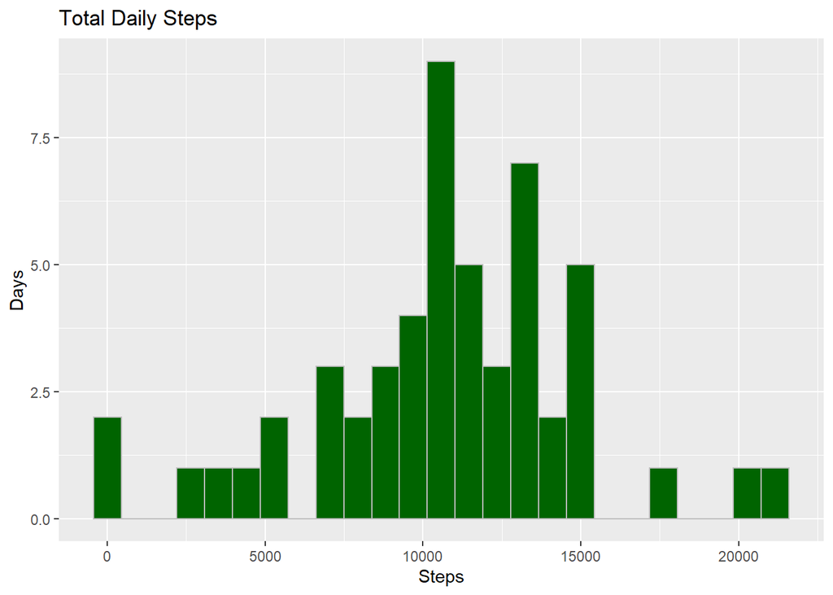

```r
library(ggplot2, quietly = TRUE)

#summarize steps per day
daysteps<- with(activity2,tapply(steps,date,sum))

#plot
qplot(daysteps, main="Total Daily Steps", ylab = "Days", xlab = "Steps",
      bins=25, fill=I("dark green"), col=I("gray"))
```

```r
#get average statistics
mn<- round(mean(daysteps),0)
md<- median(daysteps)
```

The number of daily steps has a mean of 10,766 and a median of 10,765.

Next, the average number of steps over the course of a day:

```r
library(plyr, quietly = TRUE)
library(dplyr, quietly = TRUE)
#summarize steps per interval - mean and standard deviation
timesteps<- activity2 %>%
            group_by(as.character(interval)) %>%
            summarize(mn_steps=mean(steps),std_step=sd(steps)) %>%
            rename(interval_chr="as.character(interval)") %>%
            mutate(interval=case_when(
                  is.na(hms(interval_chr)) & is.na(ms(interval_chr)) ~ hms("00:00:00"),
                  is.na(hms(interval_chr)) & !is.na(ms(interval_chr)) ~ ms(interval_chr),
                  TRUE ~ hms(interval_chr)))%>%
            arrange(as_datetime(interval))
```

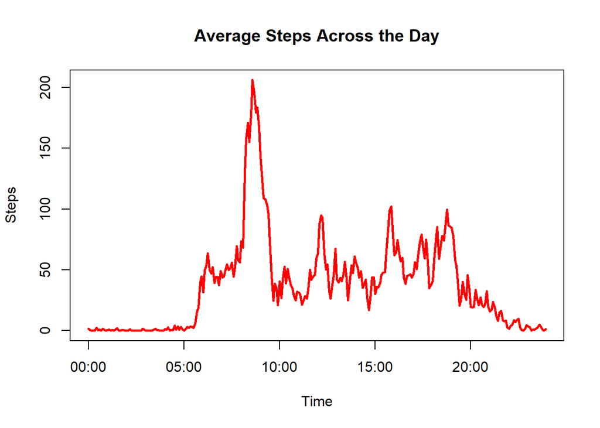

```r
#plot
plot(as_datetime(timesteps$interval),timesteps$mn_steps, type='l',
     main="Average Steps Across the Day", ylab = "Steps", xlab = "Time",
     col="red", lwd=2.5)
```

```r
#get max stats
max<- max(timesteps$mn_steps)
timeMax<- as_datetime(timesteps$interval)[timesteps$mn_steps==max]
```

On average, steps peak at 08:35 with 206 steps.

```r
#number of rows with missing values
NA_rows<- length(activity$steps[is.na(activity$steps)])

#create variables for merging
timesteps$mg<- as_datetime(timesteps$interval)
activity$mg<-  as_datetime(activity$interval)

#merge activity data with summary data
activity3<-merge(activity, timesteps, by="mg",all=TRUE)
activity3<- activity3%>%
      select(steps,date,interval.x,mn_steps,std_step)%>%
      arrange(date,as_datetime(interval.x))%>%

#simulate missing values using mean of each time interval with poisson distribution
mutate(new_steps=ifelse(!is.na(steps),steps,rpois(10000,lambda=mn_steps)))

#get average statistics, including imputed data
daysteps2<- with(activity3,tapply(new_steps,date,sum))
mn2<- round(mean(daysteps2),0)
md2<- median(daysteps2)
```

With the missing days, there are 2304 rows with missing values.

We can impute the missing data by picking from a poisson distribution based on the average number of steps for each interval. If we do so, the distribution of steps per day looks like this:

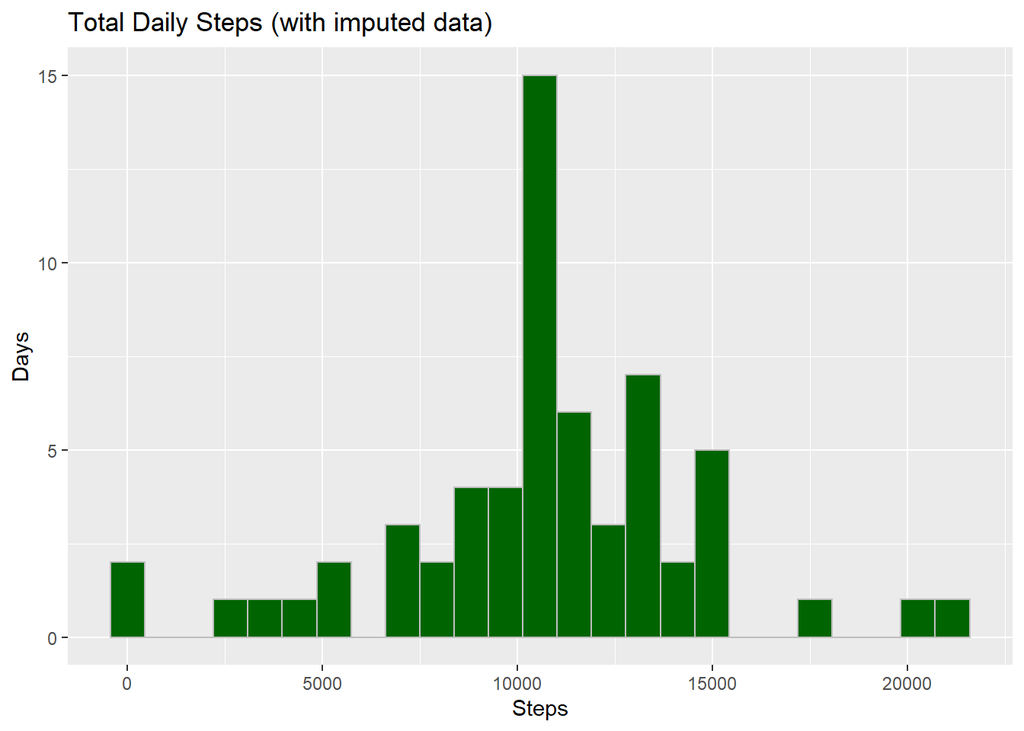

```r
qplot(daysteps2, main="Total Daily Steps (with imputed data)", ylab = "Days", xlab = "Steps",
      bins=25, fill=I("dark green"), col=I("gray"))
```

It is possible that our imputation might be more accurate if we took into account the day of the week. Let’s see if there is a difference in activity between weekend and weekday activity. This analysis uses the imputed data.

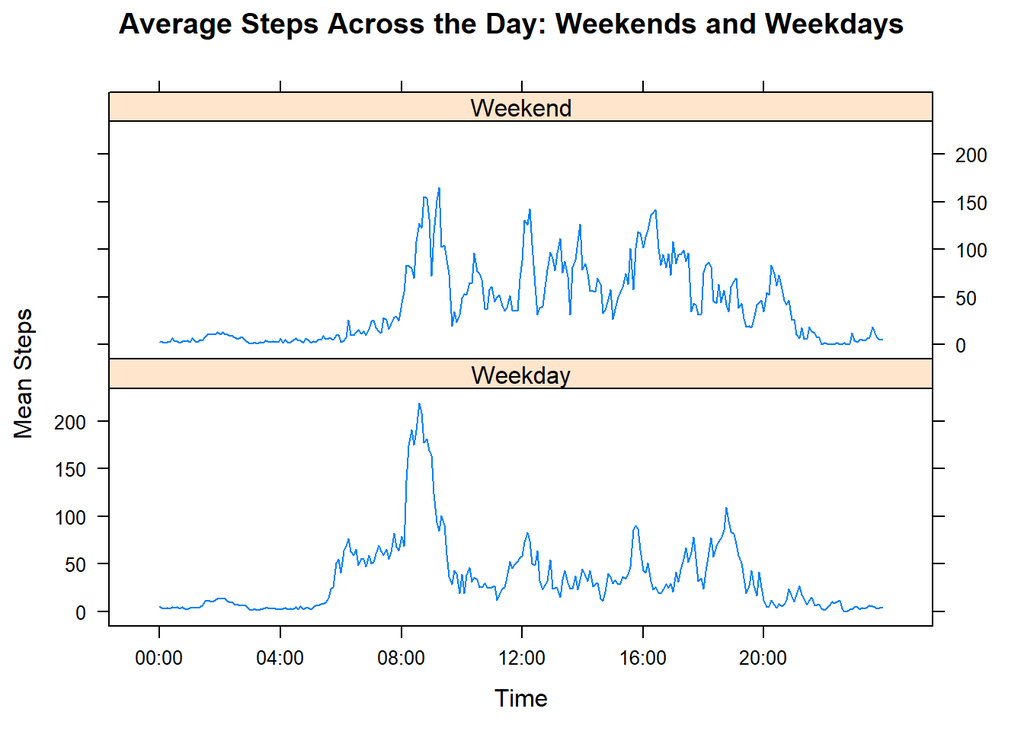

```r
library(lattice)

#add variable for weekend status
activity3<- mutate(activity3,weekday=as.factor(case_when(
            weekdays(date) %in% c("Saturday","Sunday") ~ "Weekend",
            TRUE ~ "Weekday")))

#summarize by weekend status and time
wksteps<-  activity3 %>%
      group_by(as_datetime(interval.x),weekday) %>%
      summarize(mean_steps=mean(new_steps)) %>%
      rename(interval="as_datetime(interval.x)")

#plot
tm<- as.POSIXct(wksteps$interval)
with(wksteps,xyplot(mean_steps~interval|weekday, layout=c(1,2), type="l",
                    main="Average Steps Across the Day: Weekends and Weekdays", xlab="Time", ylab="Mean Steps",
                    scales=list(x=list(at=  seq( tm[1], tm[576], by="4 hour") ,
                                       labels=format( seq( tm[1], tm[576], by="4 hour") , "%H:%M")) )
                                ))
```

It seems that weekday steps are more concentrated in the morning, while weekend steps are more evenly spread out through the day. Imputation would most likely be improved by creating means for weekends and weekdays separately.